# Chi Squared Test

```r
library(mosaic)
library(tidyverse)
library(car)
library(haven)
library(pander)
library(kableExtra)
gss2021 <- read_sas("../../Data/gss2021.sas7bdat",
    NULL)
```

```r
marital<- table(gss2021$MARITAL)
satfin <- table(gss2021$SATFIN)

my_table <- table(gss2021$MARITAL,gss2021$SATFIN)

rownames(my_table) <-c("Married", "Widowed", "Divorced", "Separated", "Never_Married")
colnames(my_table) <- c("Pretty Well Satisfied", "More or Less Satisfied", "Not Satisfied At All")
```

## Background

The data for the analysis below comes from GSS Data (General Social Survey) conducted by NORC at the University of Chicago. It’s a survey that monitors trends in American attitudes, behaviors, and social characteristics since 1972. The data that will be analyzed is coming from two 2021 surveys:

**Marital Survey:**

Are you currently–married, widowed, divorced, separated, or have you never been married?

**Financial Satisfaction Survey:**

We are interested in how people are getting along financially these days. So far as you and your family are concerned, would you say that you are pretty well satisfied with your present financial situation, more or less satisfied, or not satisfied at all?

The question that this analysis hopes to answer is:

**Does Marital Status Affect a Person’s Percieved Financial Satisfaction?**

## Hypothesis

$$H_0: \text{Financial Satisfaction and
Marital Status are Independent}$$
$$H_a : \text{Financial Satisfaction and Marital
Status are Not Independent (are associated)}$$
$$\alpha = 0.05$$

## Analysis

Before we run the chi squared test of independence, we can take a look at a table of the raw observed counts of financial satisfaction across marital status.

```r
kbl(my_table, caption = "Raw counts of Financial Satisfaction across Marital Status") %>%
  kable_styling(full_width = FALSE) %>%
  row_spec(0, extra_css = "padding:7px;") %>%
  column_spec(1:ncol(my_table), extra_css = "padding:2px;")
```

Raw counts of Financial Satisfaction across Marital Status

|  | Pretty Well Satisfied | More or Less Satisfied | Not Satisfied At All |
| --- | --- | --- | --- |
| Married | 776 | 899 | 316 |
| Widowed | 103 | 138 | 58 |
| Divorced | 148 | 291 | 214 |
| Separated | 12 | 49 | 33 |
| Never_Married | 214 | 417 | 339 |

It’s difficult to see any trends with just a normal observed counts table, the following table is a proportion table where percentages are computed across rows. I chose to show this view instead of computing across columns because I believe it’s more informational to see the variation of proportion across different marital status instead of different levels of satisfaction.

```r
p_table <- round(prop.table(my_table, margin = 1) * 100, 2)

p_table_pct <- matrix(
  paste0(p_table, "%"),
  nrow = nrow(p_table),
  dimnames = dimnames(p_table)
)

kbl(p_table_pct, caption = "Proportion Table of Financial Satisfaction across Marital Status") %>%
  kable_styling(full_width = FALSE) %>%
  row_spec(0, extra_css = "padding:7px;") %>%
  column_spec(1:ncol(my_table), extra_css = "padding:2px;")
```

Proportion Table of Financial Satisfaction across Marital Status

|  | Pretty Well Satisfied | More or Less Satisfied | Not Satisfied At All |
| --- | --- | --- | --- |
| Married | 38.98% | 45.15% | 15.87% |
| Widowed | 34.45% | 46.15% | 19.4% |
| Divorced | 22.66% | 44.56% | 32.77% |
| Separated | 12.77% | 52.13% | 35.11% |
| Never_Married | 22.06% | 42.99% | 34.95% |

From the table we can see that most of the people in each marital status are more or less satisfied with their financial status. However the change is *most prominent* when we take a look at those who are “pretty well satisfied” and “not satisfied at all”. Married and widowed people have a higher proportion of those who are pretty well satisfied compared to the proportion of those who aren’t satisfied at all, while those who are divorced, separated, or never married have a higher proportion of people who arent satisfied compared to people who are pretty well satisfied with their financial situation.

To get a clearer look at this phenomenon, we can take a look at a graphical representation of the data above.

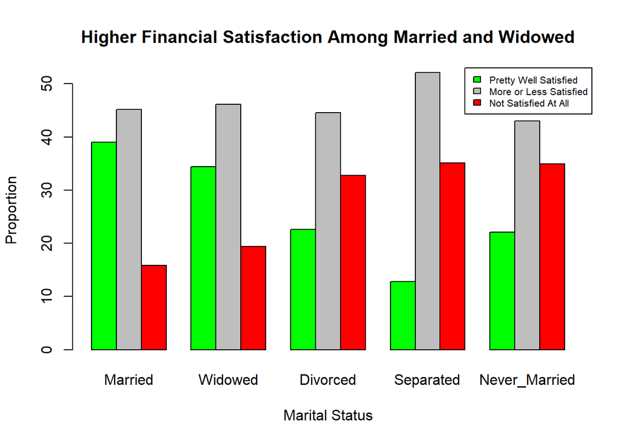

```r
bp <- barplot(t(p_table), beside = TRUE,
        col = c('green', 'gray', 'red'),
        main = "Higher Financial Satisfaction Among Married and Widowed",
        xlab = 'Marital Status',
        ylab = ' Proportion')


legend(
  x = 16,
  y = 53,
  legend = colnames(p_table),
  fill = c("green", "gray", "red"),
  xpd = TRUE,
  cex = 0.65
)
```

## Chi Squared Test of Independence

While the tables and graphs of the observed counts indicate a trend, we must verify this trend by running a Chi Squared Test of Independence Test.

```r
cheesy <- chisq.test(my_table)

cheesy %>% pander(caption = "Pearson's Chi Squared Test of Independence of Financial Satisfaction over Marital Status.")
```

Pearson’s Chi Squared Test of Independence of Financial Satisfaction over Marital Status.

| Test statistic | df | P value |
| --- | --- | --- |
| 224.7 | 8 | 3.829e-44 * * * |

Because the P-Value is < $\alpha - 0.05$ (P=3.829e-44), we **reject the null hypothesis**. There is significant evidence to indicate that Financial Satisfaction and Marital Status are not independent.

## Validity of the Chi Squared Test of Independence

To know whether or not the Chi Squared Test of Independence was a valid test to run on our data, all of the expected counts for each cell must be > 5. As we can see with the expected counts table below, our test was valid.

```r
kbl(cheesy$expected, caption = "Expected Values of Financial Satisfaction over Marital Status") %>%
  kable_styling(full_width = FALSE) %>%
  row_spec(0, extra_css = "padding:7px;") %>%
  column_spec(1:ncol(my_table), extra_css = "padding:2px;")
```

Expected Values of Financial Satisfaction over Marital Status

|  | Pretty Well Satisfied | More or Less Satisfied | Not Satisfied At All |
| --- | --- | --- | --- |
| Married | 622.59122 | 891.40354 | 477.00524 |
| Widowed | 93.49813 | 133.86723 | 71.63464 |
| Divorced | 204.19491 | 292.35887 | 156.44622 |
| Separated | 29.39406 | 42.08535 | 22.52059 |
| Never_Married | 303.32169 | 434.28500 | 232.39331 |

## Residuals of the Chi Squared Test of Independence

We can also take a look at the residuals of our test to see how different the observed counts were from the expected counts. From this we can see what contributed to our p-value being the way it is the most.

```r
kbl(cheesy$residuals, caption = "Residuals of Financial Satisfaction over Marital Status") %>%
  kable_styling(full_width = FALSE) %>%
  row_spec(0, extra_css = "padding:7px;") %>%
  column_spec(1:ncol(my_table), extra_css = "padding:2px;")
```

Residuals of Financial Satisfaction over Marital Status

|  | Pretty Well Satisfied | More or Less Satisfied | Not Satisfied At All |
| --- | --- | --- | --- |
| Married | 6.148211 | 0.2544332 | -7.371883 |
| Widowed | 0.982670 | 0.3571937 | -1.610950 |
| Divorced | -3.932552 | -0.0794731 | 4.601414 |
| Separated | -3.208272 | 1.0658711 | 2.208244 |
| Never_Married | -5.128675 | -0.8294343 | 6.993147 |

From the following table we can see that the values that influenced the p-value the most are the values we initially we observed in our numerical table and graphical summaries above. Specifically how:

• Married people have +6.14 for “pretty well satisfied” and -7.37 for “not satisfied at all”

• People who were never married have a -5.12 for “pretty well satisfied” and +6.99 for “not Satisfied at all”.

## Conclusion

From the proportion table and graphical summary of the proportion table, it’s evident that those who aren’t either Married or Widowed tend to have a higher proportion of financial unsatisfaction compared to being pretty satisfied. The opposite is true for those who are Married and Widowed.

Because our Chi Squared Test of Independence gave us a P-Value of P=3.829e-44 ($P< \alpha = 0.05$), we can trust that the trend we noticed is true. Especially since the Chi Squared Test proved to be valid for our data given the fact that the expected counts for all cells were > 5.

Furthermore, the trend is further solidified in the fact that we see the same trend in the residuals of our test with those who are married and widowed being the only ones who have positive residuals at the “pretty well satisfied” column and the only ones to have negative residuals for the not satisfied at all column.

This suggests that financial satisfaction is not distributed evenly across marital status groups. Married respondents were more financially satisfied than expected under independence, with a residual of 6.15, and widowed respondents were also slightly more financially satisfied than expected, with a residual of 0.98. In contrast, respondents who were never married were more likely than expected to report being not satisfied at all, with a residual of 6.99. Divorced respondents were also more likely than expected to report being not satisfied at all, with a residual of 4.60, followed by separated respondents at 2.20.